# R6: di che tipo sono le cellule vere nei sei tessuti, e i tipi spiegano le taglie dei nuclei?

geo_spatialtrans, report di step (protocollo v2)

Published

October 22, 2026

# In breve

## In breve: di che tipo sono le cellule vere nei sei tessuti, e i tipi spiegano le taglie dei nuclei?

**A cosa serviva.** Il simulatore oggi piazza un solo tipo di cellula per tessuto, con una sola taglia di nucleo. Sapevamo che non basta: nel cervello di topo i nuclei hanno due taglie, nel tumore del colon la taglia ha una coda troppo lunga. Per dare ai preset più tipi servono riferimenti misurati sui tessuti veri: quanti nuclei di ogni tipo, quanto grandi, che forma. Qui abbiamo dato un tipo a ciascuno dei 240 000 nuclei veri delle 30 aree di riferimento (5 per tessuto): abbiamo sommato i trascritti dei quadratini di 2 µm che cadono sul nucleo e in una corona di 8 µm attorno (quanto Space Ranger espande i nuclei, misurato dai suoi dati), raggruppato i nuclei per somiglianza di espressione e dato un nome a ogni gruppo con i geni marcatori di un atlante pubblico (PanglaoDB), secondo il catalogo di tipi che hai approvato.

**Cosa abbiamo trovato.**

1. **Il criterio con cui avevamo deciso di dare i nomi ai gruppi era sbagliato; lo abbiamo corretto, e il confronto con Space Ranger dice che la correzione è giusta.**
   - Il criterio scritto prima chiamava «endoteliali» le cellule di Paneth dell’intestino (5 260 nuclei, riconoscibili dai loro geni) e lasciava senza nome tre gruppi di cardiomiociti: quando un tipo domina il tessuto, un punteggio relativo fra gruppi si azzera proprio su quel tipo.
   - Il criterio corretto (quanto i 50 geni più caratteristici di ogni gruppo sono arricchiti nei marcatori di ciascun tipo) dà nomi coerenti con i geni in tutti e sei i tessuti.
   - Nel cervello e nel cuore, dove Space Ranger ha una sua annotazione, l’accordo sui nuclei appaiati è 91 % e 79 % con il criterio corretto (88 % e 77 % con quello scritto prima). Spostando le impronte di 20 µm l’accordo scende al livello del caso: la classificazione dipende davvero dal nucleo e non dal tessuto attorno.
   - Per regola, i verdetti delle previsioni sono dati con il criterio scritto prima; i numeri che seguono sono quelli del criterio corretto, che proponiamo come riferimento.
2. **Nel cervello di topo i nuclei dei neuroni sono circa 3 volte più grandi di quelli della glia: la previsione è confermata con il criterio corretto (con quello scritto prima resta al limite), ma il divario è molto minore di quello che avevamo letto nei due picchi.**
   - Neuroni 111 µm², glia 34 µm² (astrociti 50, oligodendrociti 31, microglia 23).
   - I neuroni sono due nuclei su tre fra quelli che Cellpose trova; la glia è sottostimata perché Cellpose perde i nuclei piccoli, come sapevamo.
   - La quota di oligodendrociti va dall’8 % al 36 % fra le 5 aree: è la sostanza bianca, e spiega gran parte della variabilità fra le aree del cervello che avevamo visto.
3. **I tipi spiegano la taglia del nucleo nell’intestino, nel tumore e nello stroma del colon (il tipo più grande supera il più piccolo del 24-42 %), ma non nel linfonodo né nel cuore.**
   - Linfonodo: i nuclei dei linfociti B e T differiscono del 5 % (16,8 contro 16,0 µm²): per i linfociti basta una sola taglia.
   - Cuore: la differenza fra tipi è dell’11 %, mentre la mediana dei soli cardiomiociti va da 16 a 28 µm² fra le aree: la variabilità del cuore non viene dai tipi (ipotesi da verificare: orientamento delle fibre nella sezione).
   - Tumore del colon: la dispersione della taglia dentro il solo epitelio (0,56 sul logaritmo dell’area) è uguale a quella di tutte le cellule insieme (0,55): la coda alta non è una mescolanza di tipi, e un modello di taglia per tipo da solo non la toglierà.
4. **I nuclei dei cardiomiociti non sono più allungati degli altri nuclei del cuore: previsione smentita.**
   - Eccentricità mediana 0,82 contro 0,83. La forma del nucleo non dice nulla sulla forma allungata della cellula: per il cuore serve una misura della cellula, non del nucleo.
5. **Le quote dei tipi ipotizzate nel documento di progetto erano quasi tutte sbagliate; ora abbiamo quelle misurate.**
   - Intestino di topo: epitelio 68 % (ipotesi 88 %), stroma e muscolo liscio 21 %, immunitarie 10 %.
   - Tumore del colon: epitelio 71 % (ipotesi 70 %), fibroblasti 20 %. Il criterio di espressione per distinguere epitelio tumorale e normale non funziona: chiama «normale» l’epitelio delle aree che il patologo ha letto come tumore.
   - Stroma del tumore: fibroblasti 32 %, epitelio 41 %, immunitarie 19 %: le aree scelte come stroma contengono molte ghiandole tumorali.
   - Linfonodo: fra i nuclei con un tipo, B 61 % nei follicoli e 42 % nella paracorticale; ma il 47 % dei nuclei resta senza tipo (46 % non risolti, 1 % con meno di 20 trascritti). Con 84 trascritti per nucleo il linfonodo è al limite di questo metodo.
   - Cuore: cardiomiociti 76 % (ipotesi 85 %), fibroblasti 13 %, immunitarie e vascolari 11 %.

**Cosa devi decidere.**

1. **Adottiamo come riferimenti le etichette del criterio corretto, invece di quelle del criterio scritto prima? Consiglio di sì.**
   - Il criterio scritto prima dà riferimenti sbagliati per costruzione nell’intestino (le cellule di Paneth come endoteliali) e nel cuore (un cardiomiocita su quattro senza tipo); quello corretto concorda di più con Space Ranger nei due tessuti dove si può controllare.
   - Alternativa: tenere il criterio scritto prima. I riferimenti dell’intestino e del cuore sarebbero inutilizzabili per i preset.
2. **Nel colon, chiamiamo «tumorale» l’epitelio delle aree che il patologo ha letto come tumore e «normale» quello delle altre, invece di affidarci al criterio di espressione? Consiglio di sì.**
   - Il criterio di espressione (geni delle cripte contro geni degli enterociti) separa gruppi di taglia diversa, non tumore e mucosa sana; le 5 aree del tumore sono tutte tumore per il patologo.
   - Alternativa: cercare marcatori tumorali con fonte. Richiederebbe uno step dedicato, senza un candidato pronto.
3. **Per il linfonodo, teniamo i riferimenti di B e T come provvisori e un’unica taglia per i linfociti? Consiglio di sì.**
   - Quasi metà dei nuclei non ha tipo e i due tipi principali hanno la stessa taglia: per il simulatore il linfonodo può restare a un tipo di taglia, con due composizioni (follicolo, paracorticale) se vorrai.
   - Alternativa: uno step dedicato con più trascritti per nucleo (bin a 8 µm o la matrice per cellula di Space Ranger): circa 2 ore di calcolo sul server con 6 processi, nessuna annotazione manuale; nel caso migliore porterebbe sotto il 10 % i nuclei senza tipo, senza cambiare la conclusione sulla taglia.

**Comunque:**

- quando porteremo i tipi nei preset useremo i riferimenti per tipo di questo step: due taglie nel cervello (neuroni e glia) con una quota di oligodendrociti che cambia fra le aree; nel tumore del colon la coda alta resta dentro l’epitelio e andrà trattata nel modello di taglia, non con i tipi;
- la forma allungata delle cellule del cuore resta da misurare sulla cellula (membrane o citoplasma), non sul nucleo;
- i riferimenti per tipo entrano nella tabella dei riferimenti biologici con la loro fonte, segnati provvisori per il linfonodo e per lo stroma del tumore (aree miste).

Appena decidi questi 3 punti, lo step è chiuso.

**Sui tempi di calcolo.** Stima dell’agente dai tempi misurati in questo step (aggregazione dei bin 2-7 minuti per dataset, clustering 1 minuto per tessuto, analisi con bootstrap circa 2 ore su un processo). L’alternativa del punto 3 ripete aggregazione e clustering sul solo linfonodo con bin a 8 µm: circa 2 ore su lesexp-server con 6 processi, entro i limiti di calcolo del progetto.

# Decisioni e verifiche di Luca

- «si va bene 1 e 2» (ok a previsioni, catalogo dei tipi e soglie, 2026-10-23)
- (decisioni 1-3 del riassunto: da trascrivere)

# Dubbi rinviati

| cosa | perché | cosa serve per chiuderlo | step destinatario | voce di BACKLOG |
| --- | --- | --- | --- | --- |
| Forma allungata del cardiomiocita (BL-064): il nucleo non è un proxy (P-3 smentita) | serve la forma della cellula, non del nucleo | segmentazione del citoplasma o delle membrane (Cellpose RGB sui profili, BL-033) in A6 e misura dell’eccentricità cellulare per tipo | step dei tipi nei preset o Step 1.5 (da assegnare) | BL-064 |
| Nel cuore l’area nucleare mediana dei cardiomiociti va da 16 a 28 µm² fra le ROI, non spiegata dai tipi (P-2 A6 smentita) | ipotesi: orientamento delle fibre nella sezione, oppure differenze della maschera di consenso R3b fra ROI | misurare l’orientamento dei nuclei per ROI e il rapporto area/eccentricità; confrontare con la maschera StarDist | da assegnare | BL-147 |
| Linfonodo: 47 % dei nuclei senza tipo (46 % non risolti + 1 % non classificabili; 84 UMI mediani per nucleo) | il clustering a 2 µm è al limite nel tessuto più denso | bin a 8 µm o matrice per cellula di Space Ranger con trasferimento delle etichette; ripetere P-4, P-5 | da assegnare (decisione 3) | BL-148 |
| Le ROI «stroma» (A3) contengono il 41 % di epitelio | le regioni stromali scelte in R2 sono miste (BL-018: A3 senza dataset dedicato) | riferimenti di A3 calcolati sui soli nuclei non epiteliali, oppure nuove ROI stromali | step dei tipi nei preset | BL-149 |
| Distinzione epitelio tumorale / normale dall’espressione non funziona (P-5 A2) | il proxy cripte/enterociti separa per taglia, non per malignità | marcatori tumorali con fonte, oppure etichetta istologica della ROI (decisione 2) | step dei tipi nei preset | BL-150 |
| Soglie di CP-1 e CP-2 mal poste (statistica max/min distorta sotto il nullo; accordo per caso alto dove un tipo domina) | errore di pre-registrazione, corretto post hoc con il confronto col nullo (PH-3) e il kappa (PH-2) | nelle prossime pre-registrazioni: soglie delle controprove derivate dalla distribuzione nulla simulata prima del calcolo | lezione di metodo | BL-151 |

# Cancelli

Pre-registrazione: commit `90404d8` (cancelli e previsioni), ok di Luca il 2026-10-23 («si va bene 1 e 2»), commit `424add0`; codice `13cd54a`.

Cancelli

| id | controllo | esito |
| --- | --- | --- |
| G-1 | batteria di test dell’attribuzione bin→nucleo e 3 mutanti (`tools/R6_test.py`) | PASS 17/17 (mutanti 3/3 rilevati) |
| G-2 | md5 di 84 file reali letti, prima e dopo (`tools/R6_md5.sh`) | PASS, identici |
| G-3 | riproducibilità: secondo run con il seme dichiarato, cluster ed etichette per nucleo (`tools/R6_repro.sh`) | PASS 6/6 identici |
| G-4 | coerenza: 102 controlli su conteggi ed etichette (`tools/R6_check.py`) | PASS 102/102 |
| G-5 | revisione avversariale: ricalcolo indipendente di frazioni, aree mediane e previsioni | vedi «Revisione avversariale» |

# Previsioni

Le previsioni si giudicano con il metodo di etichettatura pre-registrato (punteggio dei marcatori standardizzato fra cluster), come scritto. Il criterio corretto post hoc (PH-1, arricchimento ipergeometrico dei 50 geni più differenziali di ogni cluster nei marcatori PanglaoDB) è riportato accanto, perché è quello che proponiamo come riferimento (decisione 1). Intervalli: bootstrap per blocchi sulle 5 ROI per tessuto (a due stadi per le mediane), B = 2000, seme 20261022; l’intervallo riportato è il 2.5-97.5 % del bootstrap.

Previsioni P-1…P-6 per tessuto, con le due etichettature

| id | tessuto | quantità | intervallo di rilevanza | etichette | osservato [IC 95 %] | esito |
| --- | --- | --- | --- | --- | --- | --- |
| P-1 | cervello di topo | median nuclear area neurons / glia | ≥ 2.100 | PH-1 (corretto) | 3.216 [2.541, 3.682] | confermata |
| P-1 | cervello di topo | median nuclear area neurons / glia | ≥ 2.100 | pre-registrato | 2.504 [2.095, 2.952] | indeterminata |
| P-2 | intestino di topo | max/min median nuclear area among types >= 5 % | ≥ 1.095 | PH-1 (corretto) | 1.240 [1.233, 1.295] | confermata |
| P-2 | intestino di topo | max/min median nuclear area among types >= 5 % | ≥ 1.095 | pre-registrato | 1.480 [1.350, 1.639] | confermata |
| P-2 | tumore del colon | max/min median nuclear area among types >= 5 % | ≥ 1.161 | PH-1 (corretto) | 1.388 [1.347, 1.667] | confermata |
| P-2 | tumore del colon | max/min median nuclear area among types >= 5 % | ≥ 1.161 | pre-registrato | 1.569 [1.359, 1.792] | confermata |
| P-2 | stroma del tumore | max/min median nuclear area among types >= 5 % | ≥ 1.216 | PH-1 (corretto) | 1.424 [1.350, 1.686] | confermata |
| P-2 | stroma del tumore | max/min median nuclear area among types >= 5 % | ≥ 1.216 | pre-registrato | 1.309 [1.257, 1.612] | confermata |
| P-2 | linfonodo | max/min median nuclear area among types >= 5 % | ≥ 1.062 | PH-1 (corretto) | 1.047 [1.023, 1.061] | smentita |
| P-2 | linfonodo | max/min median nuclear area among types >= 5 % | ≥ 1.062 | pre-registrato | 1.106 [1.070, 1.131] | confermata |
| P-2 | cervello di topo | max/min median nuclear area among types >= 5 % | ≥ 2.096 | PH-1 (corretto) | 3.583 [3.201, 6.705] | confermata |
| P-2 | cervello di topo | max/min median nuclear area among types >= 5 % | ≥ 2.096 | pre-registrato | 2.992 [2.749, 5.874] | confermata |
| P-2 | cuore | max/min median nuclear area among types >= 5 % | ≥ 1.808 | PH-1 (corretto) | 1.113 [1.046, 1.227] | smentita |
| P-2 | cuore | max/min median nuclear area among types >= 5 % | ≥ 1.808 | pre-registrato | 1.224 [1.128, 1.317] | smentita |
| P-3 | cuore | median nuclear eccentricity cardiomyocytes - others | ≥ 0.104 | PH-1 (corretto) | -0.011 [-0.043, 0.013] | smentita |
| P-3 | cuore | median nuclear eccentricity cardiomyocytes - others | ≥ 0.104 | pre-registrato | -0.016 [-0.052, 0.010] | smentita |
| P-4 | linfonodo | B fraction follicular (f1,f2) - paracortical (p1-p3) | ≥ 0.200 | PH-1 (corretto) | 0.167 [0.112, 0.233] | indeterminata |
| P-4 | linfonodo | B fraction follicular (f1,f2) - paracortical (p1-p3) | ≥ 0.200 | pre-registrato | 0.060 [0.050, 0.070] | smentita |
| P-5 | intestino di topo | fraction of epiteliale | [0.730, 1.030] | PH-1 (corretto) | 0.685 [0.669, 0.697] | smentita |
| P-5 | intestino di topo | fraction of epiteliale | [0.730, 1.030] | pre-registrato | 0.374 [0.356, 0.391] | smentita |
| P-5 | tumore del colon | fraction of epiteliale tumorale | [0.550, 0.850] | PH-1 (corretto) | 0.050 [0.028, 0.071] | smentita |
| P-5 | tumore del colon | fraction of epiteliale tumorale | [0.550, 0.850] | pre-registrato | 0.247 [0.179, 0.324] | smentita |
| P-5 | stroma del tumore | fraction of fibroblasti+muscolo liscio | [0.600, 0.900] | PH-1 (corretto) | 0.324 [0.254, 0.428] | smentita |
| P-5 | stroma del tumore | fraction of fibroblasti+muscolo liscio | [0.600, 0.900] | pre-registrato | 0.264 [0.202, 0.354] | smentita |
| P-5 | linfonodo | fraction of linfociti B (follicular ROIs) | [0.650, 0.950] | PH-1 (corretto) | 0.370 [0.357, 0.384] | smentita |
| P-5 | linfonodo | fraction of linfociti B (follicular ROIs) | [0.650, 0.950] | pre-registrato | 0.146 [0.143, 0.149] | smentita |
| P-5 | cervello di topo | fraction of neuroni | [0.250, 0.550] | PH-1 (corretto) | 0.652 [0.579, 0.733] | smentita |
| P-5 | cervello di topo | fraction of neuroni | [0.250, 0.550] | pre-registrato | 0.609 [0.543, 0.694] | indeterminata |
| P-5 | cuore | fraction of cardiomiociti | [0.700, 1.000] | PH-1 (corretto) | 0.757 [0.685, 0.819] | indeterminata |
| P-5 | cuore | fraction of cardiomiociti | [0.700, 1.000] | pre-registrato | 0.558 [0.470, 0.660] | smentita |
| P-6 | cervello di topo | agreement with Space Ranger 10x Cloud coarse type (matched, informative) | ≥ 0.750 | PH-1 (corretto) | 0.907 [0.893, 0.935] | confermata |
| P-6 | cervello di topo | agreement with Space Ranger 10x Cloud coarse type (matched, informative) | ≥ 0.750 | pre-registrato | 0.881 [0.855, 0.915] | confermata |
| P-6 | cuore | agreement with Space Ranger 10x Cloud coarse type (matched, informative) | ≥ 0.750 | PH-1 (corretto) | 0.794 [0.746, 0.837] | indeterminata |
| P-6 | cuore | agreement with Space Ranger 10x Cloud coarse type (matched, informative) | ≥ 0.750 | pre-registrato | 0.774 [0.707, 0.826] | indeterminata |

Conteggio degli esiti con le etichette pre-registrate: 6 confermate, 8 smentite, 3 indeterminate su 17. Con PH-1: 6 confermate, 8 smentite, 3 indeterminate.

# Controprove

CP-1 (nullo per permutazione delle etichette dentro ogni ROI, 200 permutazioni): soglia pre-registrata e verdetto come scritto

| tessuto | etichette | quantity | median_null | q975_null | threshold | verdict |
| --- | --- | --- | --- | --- | --- | --- |
| intestino di topo | pre-registrato | max/min median area, labels permuted within ROI | 1.017 | 1.029 | 1.05 | PASS |
| tumore del colon | pre-registrato | max/min median area, labels permuted within ROI | 1.042 | 1.066 | 1.05 | FAIL |
| stroma del tumore | pre-registrato | max/min median area, labels permuted within ROI | 1.037 | 1.074 | 1.05 | FAIL |
| linfonodo | pre-registrato | max/min median area, labels permuted within ROI | 1.005 | 1.010 | 1.05 | PASS |
| cervello di topo | pre-registrato | max/min median area, labels permuted within ROI | 1.090 | 1.164 | 1.05 | FAIL |
| cervello di topo | pre-registrato | neuron/glia area ratio, permuted | 1.035 | 1.086 | 1.05 | FAIL |
| cuore | pre-registrato | max/min median area, labels permuted within ROI | 1.043 | 1.098 | 1.05 | FAIL |
| cuore | pre-registrato | ecc diff cardiomyocytes - others, permuted | 0.008 | 0.022 | 0.01 | FAIL |
| intestino di topo | PH-1 | max/min median area, labels permuted within ROI | 1.012 | 1.026 | 1.05 | PASS |
| tumore del colon | PH-1 | max/min median area, labels permuted within ROI | 1.007 | 1.025 | 1.05 | PASS |
| stroma del tumore | PH-1 | max/min median area, labels permuted within ROI | 1.042 | 1.073 | 1.05 | FAIL |
| linfonodo | PH-1 | max/min median area, labels permuted within ROI | 1.005 | 1.005 | 1.05 | PASS |
| cervello di topo | PH-1 | max/min median area, labels permuted within ROI | 1.113 | 1.189 | 1.05 | FAIL |
| cervello di topo | PH-1 | neuron/glia area ratio, permuted | 1.067 | 1.114 | 1.05 | FAIL |
| cuore | PH-1 | max/min median area, labels permuted within ROI | 1.031 | 1.088 | 1.05 | FAIL |
| cuore | PH-1 | ecc diff cardiomyocytes - others, permuted | 0.002 | 0.018 | 0.01 | FAIL |

PH-3: osservato contro il nullo per permutazione

| variant | tessuto | quantity | observed | observed_lo | observed_hi | null_median | null_q975 | beyond_null |
| --- | --- | --- | --- | --- | --- | --- | --- | --- |
| prereg | intestino di topo | max/min median area, labels permuted within ROI | 1.480 | 1.350 | 1.639 | 1.017 | 1.029 | True |
| prereg | tumore del colon | max/min median area, labels permuted within ROI | 1.569 | 1.359 | 1.792 | 1.042 | 1.066 | True |
| prereg | stroma del tumore | max/min median area, labels permuted within ROI | 1.309 | 1.257 | 1.612 | 1.037 | 1.074 | True |
| prereg | linfonodo | max/min median area, labels permuted within ROI | 1.106 | 1.070 | 1.131 | 1.005 | 1.010 | True |
| prereg | cervello di topo | max/min median area, labels permuted within ROI | 2.992 | 2.749 | 5.874 | 1.090 | 1.164 | True |
| prereg | cervello di topo | neuron/glia area ratio, permuted | 2.504 | 2.095 | 2.952 | 1.035 | 1.086 | True |
| prereg | cuore | max/min median area, labels permuted within ROI | 1.224 | 1.128 | 1.317 | 1.043 | 1.098 | True |
| prereg | cuore | ecc diff cardiomyocytes - others, permuted | -0.016 | -0.052 | 0.010 | 0.008 | 0.022 | False |
| ph1 | intestino di topo | max/min median area, labels permuted within ROI | 1.240 | 1.233 | 1.295 | 1.012 | 1.026 | True |
| ph1 | tumore del colon | max/min median area, labels permuted within ROI | 1.388 | 1.347 | 1.667 | 1.007 | 1.025 | True |
| ph1 | stroma del tumore | max/min median area, labels permuted within ROI | 1.424 | 1.350 | 1.686 | 1.042 | 1.073 | True |
| ph1 | linfonodo | max/min median area, labels permuted within ROI | 1.047 | 1.023 | 1.061 | 1.005 | 1.005 | True |
| ph1 | cervello di topo | max/min median area, labels permuted within ROI | 3.583 | 3.201 | 6.705 | 1.113 | 1.189 | True |
| ph1 | cervello di topo | neuron/glia area ratio, permuted | 3.216 | 2.541 | 3.682 | 1.067 | 1.114 | True |
| ph1 | cuore | max/min median area, labels permuted within ROI | 1.113 | 1.046 | 1.227 | 1.031 | 1.088 | False |
| ph1 | cuore | ecc diff cardiomyocytes - others, permuted | -0.011 | -0.043 | 0.013 | 0.002 | 0.018 | False |

CP-2 (impronte spostate di 20 µm): frazione di cluster non risolti e accordo con Space Ranger, soglia pre-registrata < 0.5

| tessuto | etichette | primary | shifted | agreement_primary | agreement_shift | verdict |
| --- | --- | --- | --- | --- | --- | --- |
| intestino di topo | pre-registrato | 0.125 | 0.176 | NA | NA |  |
| tumore del colon | pre-registrato | 0.188 | 0.261 | NA | NA |  |
| stroma del tumore | pre-registrato | 0.176 | 0.133 | NA | NA |  |
| linfonodo | pre-registrato | 0.116 | 0.121 | NA | NA |  |
| cervello di topo | pre-registrato | 0.050 | 0.077 | 0.881 | 0.506 | FAIL |
| cuore | pre-registrato | 0.231 | 0.231 | 0.774 | 0.709 | FAIL |
| intestino di topo | PH-1 | 0.000 | 0.059 | NA | NA |  |
| tumore del colon | PH-1 | 0.125 | 0.087 | NA | NA |  |
| stroma del tumore | PH-1 | 0.000 | 0.000 | NA | NA |  |
| linfonodo | PH-1 | 0.804 | 0.791 | NA | NA |  |
| cervello di topo | PH-1 | 0.000 | 0.000 | 0.907 | 0.529 | FAIL |
| cuore | PH-1 | 0.000 | 0.000 | 0.794 | 0.756 | FAIL |

PH-2: accordo con Space Ranger, accordo atteso per caso dalle marginali e kappa di Cohen, impronta giusta contro spostata

| id | variant | archetype | footprint | n | agreement | chance_agreement | kappa |
| --- | --- | --- | --- | --- | --- | --- | --- |
| PH-2 | prereg | A5 | primary | 2383 | 0.881 | 0.428 | 0.792 |
| PH-2 | prereg | A5 | shifted | 2078 | 0.506 | 0.424 | 0.142 |
| PH-2 | prereg | A6 | primary | 3550 | 0.774 | 0.662 | 0.330 |
| PH-2 | prereg | A6 | shifted | 3378 | 0.709 | 0.675 | 0.104 |
| PH-2 | ph1 | A5 | primary | 2401 | 0.907 | 0.449 | 0.831 |
| PH-2 | ph1 | A5 | shifted | 2385 | 0.529 | 0.456 | 0.134 |
| PH-2 | ph1 | A6 | primary | 4415 | 0.794 | 0.710 | 0.290 |
| PH-2 | ph1 | A6 | shifted | 4389 | 0.756 | 0.728 | 0.102 |

**CP-2 come scritta fallisce** nel cervello (0.51-0.53 contro < 0.5) e nel cuore (0.71-0.76). Anche qui la soglia era mal posta: dove un tipo domina (cardiomiociti 76 %, neuroni 65 %) un’impronta spostata di 20 µm cade quasi sempre su una cellula dello stesso tipo e l’accordo per caso è alto (0.71 nel cuore, 0.45 nel cervello). Corretto per il caso, l’accordo con Space Ranger va da kappa 0.83 a 0.13 nel cervello e da 0.29 a 0.10 nel cuore: l’impronta spostata non porta informazione sul nucleo oltre la composizione locale, che è ciò che la controprova voleva mostrare. Il kappa basso del cuore anche con l’impronta giusta (0.29) dice che i tipi minoritari del cuore sono i meno affidabili.

# Il criterio di etichettatura: pre-registrato e corretto (PH-1)

Il criterio pre-registrato (media, sui geni marcatori di un tipo, dell’espressione media del cluster standardizzata fra cluster; «non risolto» se il punteggio migliore è sotto zero) ha due difetti visibili nelle tabelle dei cluster: (1) nell’intestino il cluster delle cellule di Paneth (Defa21, Lyz1, Itln1, Ang4; 5 260 nuclei) ha punteggio «endoteliale» 0.68 contro «epiteliale» 0.06, perché la media su 390 geni epiteliali diluisce i marcatori di Paneth; (2) nel cuore tre cluster con TNNT2, TNNI3, TNNC1 fra i primi geni restano «non risolti» perché, quando un tipo occupa 10 cluster su 13, la standardizzazione fra cluster azzera il suo punteggio nei cluster tipici. Un primo tentativo di correzione con il punteggio per nucleo contro geni di controllo (scanpy `score_genes`) ha fallito nella direzione opposta (tutto il cuore cardiomiociti: i trascritti del muscolo saturano ogni impronta). Il criterio PH-1 (arricchimento ipergeometrico dei 50 geni più differenziali del cluster in ogni insieme di marcatori; tipo = insieme con la p più piccola se p < 0.01/numero di tipi) è relativo fra cluster e insensibile alla taglia degli insiemi; dà etichette coerenti con i geni in tutti i tessuti e un accordo con Space Ranger più alto (P-6). Le tabelle dei cluster con i geni per il controllo umano sono in `/mnt/micron/geo_spatialtrans/R6/labels/*_clusters*.csv`.

Sensibilità (etichette PH-1): accordo delle etichette per nucleo con il run primario (impronta espansa, UMI ≥ 20, seme 20261022)

| tessuto | variant | n_both_typed | label_agreement | ari_clusters | frac_nontype_alt |
| --- | --- | --- | --- | --- | --- |
| intestino di topo | footprint nucleus only | 35016 | 0.804 | 0.236 | 0.095 |
| intestino di topo | UMI >= 10 | 38681 | 0.896 | 0.682 | 0.000 |
| intestino di topo | UMI >= 40 | 38647 | 0.862 | 0.769 | 0.001 |
| intestino di topo | Leiden seed 7 | 38681 | 0.901 | 0.736 | 0.000 |
| tumore del colon | footprint nucleus only | 22924 | 0.640 | 0.223 | 0.238 |
| tumore del colon | UMI >= 10 | 29892 | 1.000 | 1.000 | 0.086 |
| tumore del colon | UMI >= 40 | 23921 | 0.906 | 0.679 | 0.200 |
| tumore del colon | Leiden seed 7 | 27928 | 0.923 | 0.650 | 0.078 |
| stroma del tumore | footprint nucleus only | 19197 | 0.630 | 0.214 | 0.099 |
| stroma del tumore | UMI >= 10 | 21241 | 0.825 | 0.436 | 0.002 |
| stroma del tumore | UMI >= 40 | 21232 | 0.757 | 0.554 | 0.003 |
| stroma del tumore | Leiden seed 7 | 21241 | 0.893 | 0.421 | 0.003 |
| linfonodo | footprint nucleus only | 26884 | 0.694 | 0.165 | 0.751 |
| linfonodo | UMI >= 10 | 59869 | 0.907 | 0.643 | 0.471 |
| linfonodo | UMI >= 40 | 58028 | 0.795 | 0.504 | 0.409 |
| linfonodo | Leiden seed 7 | 65674 | 0.945 | 0.875 | 0.489 |
| cervello di topo | footprint nucleus only | 3883 | 0.856 | 0.184 | 0.063 |
| cervello di topo | UMI >= 10 | 4141 | 0.934 | 0.611 | 0.000 |
| cervello di topo | UMI >= 40 | 4136 | 0.950 | 0.603 | 0.001 |
| cervello di topo | Leiden seed 7 | 4141 | 0.952 | 0.710 | 0.000 |
| cuore | footprint nucleus only | 2200 | 0.675 | 0.040 | 0.553 |
| cuore | UMI >= 10 | 4922 | 0.826 | 0.426 | 0.000 |
| cuore | UMI >= 40 | 4707 | 0.823 | 0.496 | 0.044 |
| cuore | Leiden seed 7 | 4299 | 0.902 | 0.541 | 0.127 |

# Revisione avversariale

Due revisori indipendenti (sotto-agenti con accesso al server e ai file, senza accesso a questa conversazione), prima del verdetto. I loro documenti sono in `results/R6/review/` (`R6_review_numeric.csv`, `R6_review_numeric_notes.md`, `R6_review_code.md`, script e output in `code_checks/`).

**Revisore numerico** (ricalcolo indipendente dai file delle etichette, 316 confronti con le tabelle dei risultati): 313 coincidono entro 1e-6; 3 discrepanze, tutte riprodotte esattamente dal revisore e quindi spiegate.

- D1, D2 (gravi): in P-6 nel cuore il filtro che esclude i nuclei appaiati a cellule «Low UMI Barcode» o «cell» di Space Ranger non agiva (`~` su una colonna di tipo oggetto in pandas 3.0 converte −2 e −1 entrambi a vero): 421 nuclei del cuore non esclusi, accordo 0.750 invece di 0.774 (pre-registrato) e 0.777 invece di 0.794 (PH-1); il cervello non era toccato. **Corretto** (`astype(bool)`) e analisi rieseguita; i valori nel report sono quelli corretti.
- D3 (lieve): la soglia «tipi con almeno il 5 % dei nuclei» di P-2 era applicata nel codice alle frazioni fra i soli nuclei risolti, mentre la pre-registrazione la riferisce a tutti i nuclei; cambiava un solo caso (tumore del colon, PH-1: rapporto 1.39 fra epitelio e fibroblasti invece di 1.62 fra epitelio e il piccolo gruppo «epiteliale tumorale» al 4.95 %). **Corretto** come pre-registrato e rieseguito; l’esito resta confermato.

**Revisore del codice** (lettura dei 5 script e controlli sui dati reali; non ha rilevato il bug D1-D2 del filtro «Low UMI», trovato invece dal ricalcolo numerico: i due controlli sono complementari, e il bilancio della revisione è un bug vero corretto, non zero: ordine delle righe e somme UMI su tutte le 30 ROI; ricalcolo indipendente dall’h5 su 3 ROI; convenzione delle coordinate; blocco dei nuclei scartati; conteggi per cluster; join dei territori; appaiamento con Space Ranger su 2 ROI; stime puntuali di tutte le tabelle, differenza massima 2e-16): nessun bug che cambi i numeri. Rilievi accolti:

- l’intervallo di P-5 nel linfonodo (2 ROI follicolari) con bootstrap a uno stadio era degenere (3 campioni distinti): **corretto** con il bootstrap a due stadi per tutte le P-5 e rieseguito;
- pareggi di distanza nell’espansione dei nuclei risolti dall’indice della trasformata di distanza: 0.21 % dei bin nell’intestino, 0.012 % nel cuore (dichiarato qui, nessuna correzione);
- catalogo dei tipi duplicato in due file (identici) e `capitalize()` sui simboli murini che perde 1 marcatore su 691 (intestino) e 1 su 400 circa (cervello): dichiarati, non corretti in questo step (BL-152);
- le repliche bootstrap non finite sono scartate in silenzio: dichiarato;
- osservazione metodologica: nel linfonodo Leiden produce 491 cluster, 243 con meno di 50 nuclei, e sono questi (dimensione mediana 46) a restare «non risolti» con PH-1; il grafo dei vicini si frammenta per i pochi trascritti per nucleo. Entra nel dubbio rinviato sul linfonodo (BL-148) con la proposta del revisore (dimensione minima di cluster o soglia di UMI più alta).

Deviazioni dichiarate dai revisori: il ricalcolo dall’h5 e il controllo dei pareggi sono su 3 e 2 ROI, non su 30; la ricostruzione del grafo del linfonodo non è identica bit per bit alla corsa originale; il bootstrap è stato controllato per lettura del codice, non rieseguito.

# Cosa è girato

- Server lesexp-server, 2026-10-22/23. Commit del codice `13cd54a`; aggregazione 5 processi (143-430 s per dataset); clustering 6 processi × 2 thread (25-70 s per tessuto); sensibilità 30 run; analisi con bootstrap B = 2000 circa 2 h per etichettatura (lento sul linfonodo, 139 000 nuclei). Nessuna annotazione manuale.
- Espansione nucleo→cellula d_exp = 8.0 µm: 95° percentile della distanza bin-nucleo nei bin che Space Ranger 4 assegna alla cellula ma non al nucleo, 4 dataset, 77 542 cellule campionate (`R6_dexp.csv`). Nota: la misura di Space Ranger è centro-a-centro dei bin, la nostra espansione è dal bordo della maschera: la nostra impronta è quindi un po’ più generosa.
- Marcatori: PanglaoDB (Franzén et al. 2019) scaricati tramite OmniPath/decoupler il 2026-10-22 (il sito panglaodb.se rispondeva 504); tabelle in `/mnt/micron/geo_spatialtrans/R6/PanglaoDB_omnipath_{human,mouse}.tsv`, md5 in `R6_md5_before.txt`.
- md5 di 84 file letti identici prima e dopo (`R6_md5_before.txt`, `R6_md5_after.txt`).

# Appendice

## Riferimenti per tipo (etichette PH-1)

Per tessuto e tipo: n, frazione [IC], densità media per ROI (nuclei/mm² di tessuto netto), area nucleare mediana [IC], eccentricità mediana, area mediana del territorio (celle interne), N/T mediano, UMI mediani per nucleo

| tessuto | cell_type | n | frazione | density_mm2_mean_roi | area | median_ecc_nuc | median_a_t_interior | median_nt | median_umi |
| --- | --- | --- | --- | --- | --- | --- | --- | --- | --- |
| intestino di topo | epiteliale | 26500 | 0.685 [0.671, 0.696] | 7240.878 | 13.94 [13.57, 14.39] | 0.797 | 63.473 | 0.231 | 612.0 |
| intestino di topo | immunitario | 3906 | 0.101 [0.083, 0.118] | 1060.460 | 11.24 [10.87, 11.62] | 0.759 | 45.794 | 0.253 | 360.5 |
| intestino di topo | non classificabile | 6 | 0.000 [0.000, 0.000] | 2.694 | 8.62 [ NA, NA] | 0.744 | NA | NA | 3.5 |
| intestino di topo | stromale e muscolo liscio | 8275 | 0.214 [0.199, 0.232] | 2279.029 | 11.24 [10.72, 11.84] | 0.834 | 67.868 | 0.168 | 335.0 |
| tumore del colon | epiteliale normale | 21588 | 0.660 [0.587, 0.739] | 5191.476 | 33.79 [32.96, 34.83] | 0.781 | 87.700 | 0.412 | 1291.0 |
| tumore del colon | epiteliale tumorale | 1621 | 0.050 [0.028, 0.072] | 365.970 | 20.83 [17.30, 22.25] | 0.696 | 38.401 | 0.547 | 370.0 |
| tumore del colon | fibroblasti | 6683 | 0.204 [0.130, 0.277] | 1561.871 | 24.35 [20.98, 29.37] | 0.785 | 132.922 | 0.190 | 882.0 |
| tumore del colon | non classificabile | 2 | 0.000 [0.000, 0.000] | 2.321 | 28.77 [ NA, NA] | 0.537 | NA | NA | 0.0 |
| tumore del colon | non risolto | 2827 | 0.086 [0.075, 0.097] | 669.803 | 30.26 [27.49, 33.64] | 0.785 | 106.737 | 0.334 | 1257.0 |
| stroma del tumore | endoteliale | 1729 | 0.081 [0.062, 0.102] | 347.087 | 31.16 [27.42, 35.13] | 0.818 | 164.501 | 0.196 | 720.0 |
| stroma del tumore | epiteliale normale | 7055 | 0.331 [0.214, 0.445] | 1417.430 | 34.98 [31.31, 42.48] | 0.741 | 98.164 | 0.392 | 1032.0 |
| stroma del tumore | epiteliale tumorale | 1592 | 0.075 [0.048, 0.099] | 319.970 | 24.57 [22.70, 27.64] | 0.725 | 53.346 | 0.467 | 414.0 |
| stroma del tumore | fibroblasti | 6905 | 0.324 [0.251, 0.420] | 1387.118 | 31.99 [30.34, 34.09] | 0.868 | 301.760 | 0.108 | 807.0 |
| stroma del tumore | immunitario | 3960 | 0.186 [0.139, 0.232] | 795.166 | 26.29 [24.46, 28.47] | 0.804 | 186.516 | 0.143 | 683.0 |
| stroma del tumore | non classificabile | 57 | 0.003 [0.000, 0.008] | 28.601 | 21.80 [4.20, 25.02] | 0.841 | 293.821 | 0.079 | 7.0 |
| linfonodo | endoteliali | 1120 | 0.008 [0.007, 0.009] | 224.786 | 15.14 [14.84, 15.29] | 0.669 | 32.268 | 0.466 | 71.0 |
| linfonodo | linfociti B | 36352 | 0.262 [0.184, 0.344] | 7300.041 | 16.79 [16.41, 17.01] | 0.643 | 37.419 | 0.456 | 122.0 |
| linfonodo | linfociti T | 30628 | 0.220 [0.187, 0.245] | 6142.237 | 16.04 [15.89, 16.26] | 0.616 | 32.761 | 0.487 | 90.0 |
| linfonodo | mieloidi | 1486 | 0.011 [0.008, 0.014] | 298.325 | 17.01 [16.86, 17.46] | 0.635 | 39.694 | 0.443 | 136.0 |
| linfonodo | non classificabile | 1886 | 0.014 [0.009, 0.019] | 378.176 | 7.87 [7.50, 7.87] | 0.816 | 19.976 | 0.397 | 15.0 |
| linfonodo | non risolto | 63623 | 0.458 [0.402, 0.516] | 12762.282 | 14.99 [14.92, 15.14] | 0.626 | 29.875 | 0.492 | 66.0 |
| linfonodo | plasmacellule | 2345 | 0.017 [0.012, 0.024] | 471.109 | 15.67 [15.22, 16.11] | 0.660 | 34.477 | 0.451 | 100.0 |
| linfonodo | stromali | 1562 | 0.011 [0.010, 0.012] | 313.315 | 15.74 [15.37, 15.96] | 0.635 | 33.095 | 0.471 | 87.0 |
| cervello di topo | astrociti | 275 | 0.066 [0.058, 0.078] | 68.973 | 49.93 [47.46, 53.16] | 0.559 | 740.313 | 0.063 | 3148.0 |
| cervello di topo | microglia | 151 | 0.036 [0.029, 0.048] | 38.164 | 23.43 [21.33, 28.91] | 0.719 | 1099.800 | 0.028 | 3159.0 |
| cervello di topo | neuroni | 2701 | 0.652 [0.580, 0.733] | 678.491 | 110.83 [104.45, 120.74] | 0.545 | 899.307 | 0.116 | 7981.0 |
| cervello di topo | non classificabile | 1 | 0.000 [0.000, 0.001] | 1.341 | 4.96 [ NA, NA] | 0.757 | NA | NA | 13.0 |
| cervello di topo | oligodendrociti | 818 | 0.197 [0.092, 0.298] | 209.404 | 30.94 [25.53, 42.05] | 0.684 | 370.648 | 0.062 | 2000.0 |
| cervello di topo | vascolari | 196 | 0.047 [0.032, 0.063] | 48.507 | 23.39 [16.37, 67.43] | 0.730 | 1016.298 | 0.031 | 3059.0 |
| cuore | cardiomiociti | 3729 | 0.757 [0.687, 0.817] | 803.997 | 19.72 [17.09, 23.09] | 0.817 | 790.480 | 0.026 | 289.0 |
| cuore | fibroblasti | 628 | 0.128 [0.073, 0.177] | 135.980 | 19.94 [18.44, 22.42] | 0.830 | 618.319 | 0.032 | 257.0 |
| cuore | immunitari | 565 | 0.115 [0.101, 0.131] | 121.769 | 17.92 [16.04, 20.62] | 0.824 | 469.060 | 0.037 | 176.0 |
| cuore | non classificabile | 3 | 0.001 [0.000, 0.001] | 1.572 | 9.07 [ NA, NA] | 0.736 | NA | NA | 16.0 |

## Riferimenti per tipo (etichette pre-registrate)

| tessuto | cell_type | n | fraction | median_area_nuc | median_ecc_nuc | median_a_t_interior | median_nt |
| --- | --- | --- | --- | --- | --- | --- | --- |
| intestino di topo | endoteliale | 12740 | 0.329 | 13.865 | 0.812 | 64.620 | 0.215 |
| intestino di topo | epiteliale | 14461 | 0.374 | 14.090 | 0.794 | 60.635 | 0.250 |
| intestino di topo | immunitario | 5082 | 0.131 | 11.392 | 0.750 | 47.206 | 0.245 |
| intestino di topo | non classificabile | 6 | 0.000 | 8.619 | 0.744 | NA | NA |
| intestino di topo | non risolto | 2573 | 0.067 | 12.516 | 0.777 | 41.770 | 0.306 |
| intestino di topo | stromale e muscolo liscio | 3825 | 0.099 | 9.518 | 0.884 | 119.933 | 0.075 |
| tumore del colon | endoteliale | 2380 | 0.073 | 26.369 | 0.798 | 130.656 | 0.203 |
| tumore del colon | epiteliale normale | 14446 | 0.441 | 34.385 | 0.791 | 103.312 | 0.356 |
| tumore del colon | epiteliale tumorale | 8092 | 0.247 | 35.134 | 0.778 | 81.025 | 0.460 |
| tumore del colon | fibroblasti | 880 | 0.027 | 29.029 | 0.849 | 220.160 | 0.134 |
| tumore del colon | immunitario | 3262 | 0.100 | 22.399 | 0.757 | 113.877 | 0.202 |
| tumore del colon | muscolo liscio | 161 | 0.005 | 25.245 | 0.811 | 186.829 | 0.160 |
| tumore del colon | non classificabile | 2 | 0.000 | 28.766 | 0.537 | NA | NA |
| tumore del colon | non risolto | 3498 | 0.107 | 21.725 | 0.716 | 43.409 | 0.504 |
| stroma del tumore | endoteliale | 1729 | 0.081 | 31.164 | 0.818 | 164.501 | 0.196 |
| stroma del tumore | epiteliale normale | 6279 | 0.295 | 33.711 | 0.739 | 91.436 | 0.399 |
| stroma del tumore | epiteliale tumorale | 1602 | 0.075 | 30.901 | 0.743 | 81.602 | 0.428 |
| stroma del tumore | fibroblasti | 5621 | 0.264 | 34.235 | 0.880 | 316.377 | 0.109 |
| stroma del tumore | immunitario | 5244 | 0.246 | 26.144 | 0.804 | 196.878 | 0.132 |
| stroma del tumore | non classificabile | 57 | 0.003 | 21.800 | 0.841 | 293.821 | 0.079 |
| stroma del tumore | non risolto | 766 | 0.036 | 26.332 | 0.728 | 61.532 | 0.431 |
| linfonodo | endoteliali | 14139 | 0.102 | 15.290 | 0.629 | 31.051 | 0.487 |
| linfonodo | linfociti B | 14875 | 0.107 | 16.115 | 0.638 | 34.471 | 0.464 |
| linfonodo | linfociti T | 44304 | 0.319 | 15.740 | 0.616 | 31.875 | 0.490 |
| linfonodo | mieloidi | 5733 | 0.041 | 15.740 | 0.625 | 33.105 | 0.473 |
| linfonodo | non classificabile | 1886 | 0.014 | 7.870 | 0.816 | 19.976 | 0.397 |
| linfonodo | non risolto | 3934 | 0.028 | 14.016 | 0.644 | 27.224 | 0.504 |
| linfonodo | plasmacellule | 31852 | 0.229 | 16.490 | 0.644 | 36.442 | 0.459 |
| linfonodo | stromali | 22279 | 0.160 | 14.916 | 0.629 | 29.651 | 0.492 |
| cervello di topo | astrociti | 452 | 0.109 | 57.218 | 0.533 | 851.806 | 0.081 |
| cervello di topo | microglia | 169 | 0.041 | 22.226 | 0.747 | 1106.790 | 0.027 |
| cervello di topo | neuroni | 2524 | 0.609 | 110.756 | 0.549 | 899.452 | 0.117 |
| cervello di topo | non classificabile | 1 | 0.000 | 4.956 | 0.757 | NA | NA |
| cervello di topo | non risolto | 193 | 0.047 | 5.932 | 0.760 | 127.184 | 0.051 |
| cervello di topo | oligodendrociti | 625 | 0.151 | 37.019 | 0.657 | 636.577 | 0.069 |
| cervello di topo | vascolari | 178 | 0.043 | 26.168 | 0.683 | 966.587 | 0.032 |
| cuore | cardiomiociti | 2748 | 0.558 | 21.930 | 0.811 | 805.923 | 0.028 |
| cuore | endoteliali | 565 | 0.115 | 17.918 | 0.824 | 469.060 | 0.037 |
| cuore | fibroblasti | 628 | 0.128 | 19.943 | 0.830 | 618.319 | 0.032 |
| cuore | non classificabile | 3 | 0.001 | 9.072 | 0.736 | NA | NA |
| cuore | non risolto | 981 | 0.199 | 15.294 | 0.825 | 752.757 | 0.022 |

## Post hoc PH-4, PH-5, PH-6

PH-4 epitelio totale nel colon; PH-5 quote del linfonodo fra i risolti e per ROI; PH-6 dispersione del log dell’area per tipo (sigma; q01, q99)

| id | archetype | quantity | estimate | lo | hi |
| --- | --- | --- | --- | --- | --- |
| PH-6 | A1 | epiteliale: sigma of log nuclear area; q01, q99 of area (um2) | 0.465 | 4.647 | 39.422 |
| PH-6 | A1 | immunitario: sigma of log nuclear area; q01, q99 of area (um2) | 0.386 | 4.497 | 25.702 |
| PH-6 | A1 | stromale e muscolo liscio: sigma of log nuclear area; q01, q99 of area (um2) | 0.517 | 4.272 | 40.021 |
| PH-4 | A2 | fraction epithelial (tumorale + normale) | 0.709 | 0.630 | 0.790 |
| PH-6 | A2 | epiteliale normale: sigma of log nuclear area; q01, q99 of area (um2) | 0.560 | 8.091 | 113.437 |
| PH-6 | A2 | epiteliale tumorale: sigma of log nuclear area; q01, q99 of area (um2) | 0.482 | 5.484 | 55.510 |
| PH-6 | A2 | fibroblasti: sigma of log nuclear area; q01, q99 of area (um2) | 0.550 | 6.293 | 81.668 |
| PH-4 | A3 | fraction epithelial (tumorale + normale) | 0.406 | 0.249 | 0.554 |
| PH-6 | A3 | endoteliale: sigma of log nuclear area; q01, q99 of area (um2) | 0.545 | 7.662 | 92.900 |
| PH-6 | A3 | epiteliale normale: sigma of log nuclear area; q01, q99 of area (um2) | 0.561 | 9.064 | 128.394 |
| PH-6 | A3 | epiteliale tumorale: sigma of log nuclear area; q01, q99 of area (um2) | 0.501 | 6.368 | 71.800 |
| PH-6 | A3 | fibroblasti: sigma of log nuclear area; q01, q99 of area (um2) | 0.573 | 7.341 | 109.372 |
| PH-6 | A3 | immunitario: sigma of log nuclear area; q01, q99 of area (um2) | 0.533 | 6.262 | 79.935 |
| PH-5 | A4 | fraction linfociti B among resolved nuclei | 0.495 | 0.402 | 0.585 |
| PH-5 | A4 | fraction linfociti B among resolved, follicular ROIs | 0.609 | 0.581 | 0.639 |
| PH-5 | A4 | fraction linfociti B among resolved, paracortical ROIs | 0.418 | 0.331 | 0.493 |
| PH-5 | A4 | fraction linfociti T among resolved nuclei | 0.417 | 0.324 | 0.512 |
| PH-5 | A4 | fraction linfociti T among resolved, follicular ROIs | 0.298 | 0.252 | 0.341 |
| PH-5 | A4 | fraction linfociti T among resolved, paracortical ROIs | 0.496 | 0.422 | 0.581 |
| PH-5 | A4 | ROI f1: fraction unresolved / B / T (all nuclei) | 0.395 | 0.382 | 0.151 |
| PH-5 | A4 | ROI f2: fraction unresolved / B / T (all nuclei) | 0.373 | 0.359 | 0.211 |
| PH-5 | A4 | ROI p1: fraction unresolved / B / T (all nuclei) | 0.562 | 0.137 | 0.241 |
| PH-5 | A4 | ROI p2: fraction unresolved / B / T (all nuclei) | 0.460 | 0.258 | 0.221 |
| PH-5 | A4 | ROI p3: fraction unresolved / B / T (all nuclei) | 0.467 | 0.217 | 0.261 |
| PH-6 | A4 | endoteliali: sigma of log nuclear area; q01, q99 of area (um2) | 0.346 | 4.797 | 34.061 |
| PH-6 | A4 | linfociti B: sigma of log nuclear area; q01, q99 of area (um2) | 0.384 | 7.121 | 52.617 |
| PH-6 | A4 | linfociti T: sigma of log nuclear area; q01, q99 of area (um2) | 0.269 | 7.345 | 31.255 |
| PH-6 | A4 | mieloidi: sigma of log nuclear area; q01, q99 of area (um2) | 0.294 | 7.859 | 38.458 |
| PH-6 | A4 | plasmacellule: sigma of log nuclear area; q01, q99 of area (um2) | 0.382 | 4.755 | 38.076 |
| PH-6 | A4 | stromali: sigma of log nuclear area; q01, q99 of area (um2) | 0.273 | 7.345 | 31.264 |
| PH-1 detail | A5 | median nuclear area glia pooled (um2) | 34.466 | NA | NA |
| PH-5 | A5 | ROI r1: fraction neurons / oligodendrocytes / astrocytes | 0.534 | 0.362 | 0.054 |
| PH-5 | A5 | ROI r2: fraction neurons / oligodendrocytes / astrocytes | 0.707 | 0.124 | 0.067 |
| PH-5 | A5 | ROI r3: fraction neurons / oligodendrocytes / astrocytes | 0.755 | 0.085 | 0.060 |
| PH-5 | A5 | ROI r4: fraction neurons / oligodendrocytes / astrocytes | 0.725 | 0.078 | 0.084 |
| PH-5 | A5 | ROI r5: fraction neurons / oligodendrocytes / astrocytes | 0.654 | 0.180 | 0.076 |
| PH-6 | A5 | astrociti: sigma of log nuclear area; q01, q99 of area (um2) | 0.509 | 4.881 | 101.001 |
| PH-6 | A5 | microglia: sigma of log nuclear area; q01, q99 of area (um2) | 0.844 | 9.912 | 177.210 |
| PH-6 | A5 | neuroni: sigma of log nuclear area; q01, q99 of area (um2) | 0.491 | 15.919 | 219.034 |
| PH-6 | A5 | oligodendrociti: sigma of log nuclear area; q01, q99 of area (um2) | 1.049 | 4.130 | 173.015 |
| PH-6 | A5 | vascolari: sigma of log nuclear area; q01, q99 of area (um2) | 0.969 | 7.051 | 147.677 |
| PH-6 | A6 | cardiomiociti: sigma of log nuclear area; q01, q99 of area (um2) | 0.575 | 6.115 | 81.411 |
| PH-6 | A6 | fibroblasti: sigma of log nuclear area; q01, q99 of area (um2) | 0.468 | 4.798 | 54.655 |
| PH-6 | A6 | immunitari: sigma of log nuclear area; q01, q99 of area (um2) | 0.472 | 4.744 | 48.165 |

## Confusione con Space Ranger (PH-1)

Cervello di topo: righe = nostro tipo, colonne = tipo Space Ranger (10x Cloud) mappato al catalogo

| cell_type | altro | astrociti | microglia | neuroni | oligodendrociti | vascolari |
| --- | --- | --- | --- | --- | --- | --- |
| astrociti | 1 | 201 | 0 | 0 | 2 | 1 |
| microglia | 0 | 0 | 91 | 21 | 6 | 2 |
| neuroni | 0 | 29 | 0 | 1437 | 6 | 5 |
| oligodendrociti | 0 | 16 | 0 | 74 | 365 | 6 |
| vascolari | 13 | 4 | 1 | 50 | 1 | 83 |

Cuore

| cell_type | altro | cardiomiociti | endoteliali | fibroblasti | immunitari | muscolo liscio e periciti |
| --- | --- | --- | --- | --- | --- | --- |
| cardiomiociti | 42 | 3383 | 60 | 7 | 33 | 31 |
| fibroblasti | 4 | 316 | 41 | 77 | 20 | 29 |
| immunitari | 10 | 215 | 95 | 13 | 47 | 48 |

## Figure

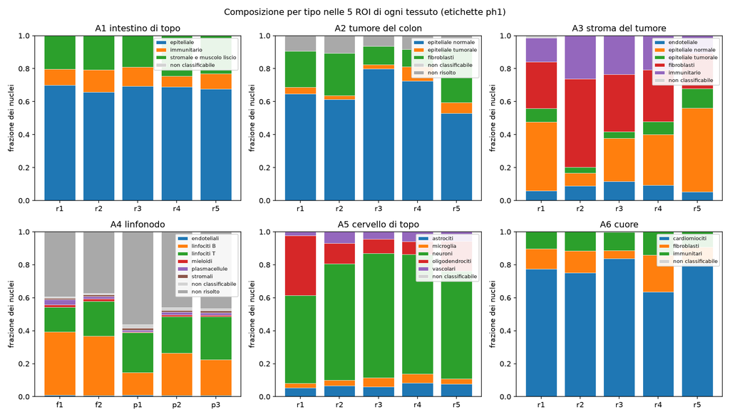

Composizione per tipo nelle 5 ROI di ogni tessuto (PH-1)

Cosa guardare: nel cervello la quota di oligodendrociti cambia da ROI a ROI (sostanza bianca); nel linfonodo la quota «non risolto» è grande in tutte le ROI.

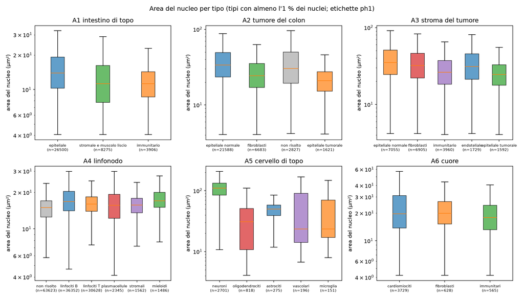

Area del nucleo per tipo (PH-1)

Cosa guardare: nel cervello i neuroni sono separati dalla glia; nel linfonodo e nel cuore le scatole dei tipi si sovrappongono.

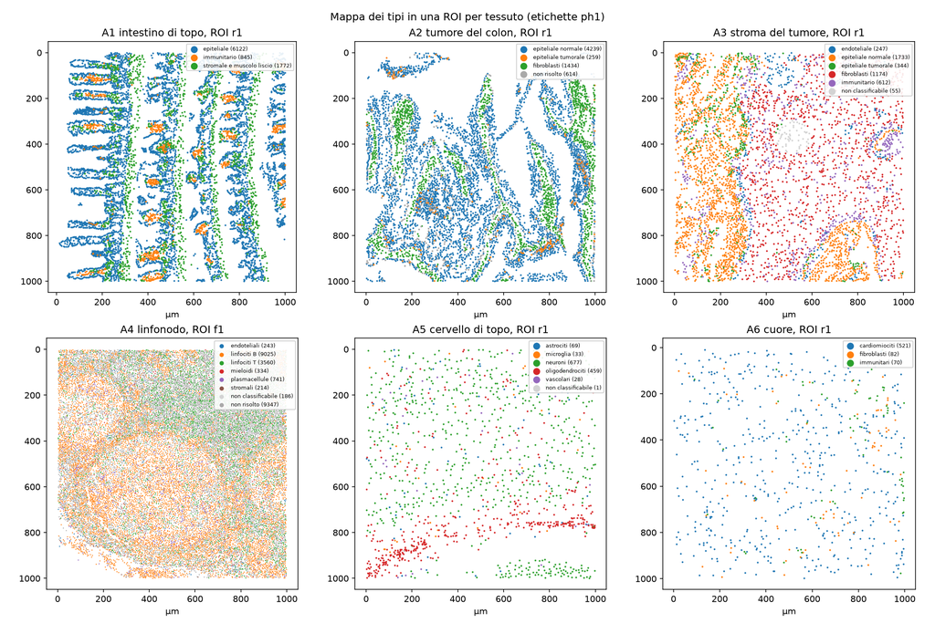

Mappa dei tipi in una ROI per tessuto (PH-1)

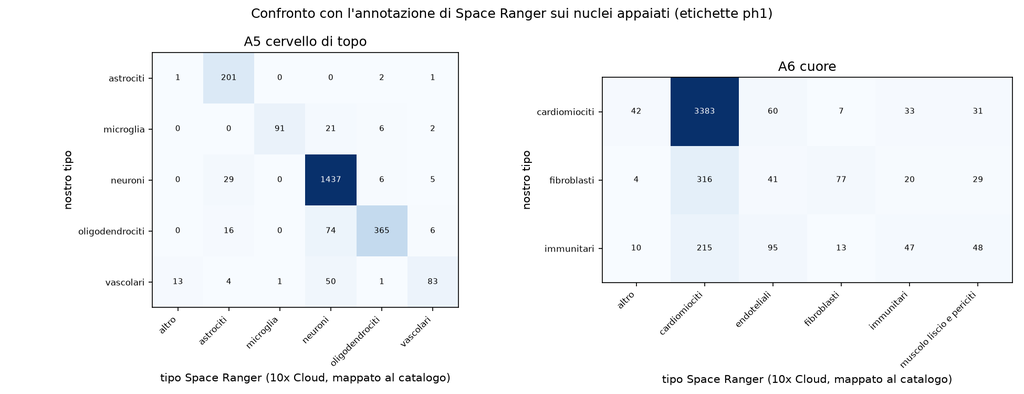

Confronto con Space Ranger (PH-1)

## Da dove vengono i numeri del riassunto

| frase del riassunto | fonte (tabella o file, riga) | valore letto |
| --- | --- | --- |
| 240 000 nuclei veri delle 30 aree | R6_refs_type_ph1.csv, somma di n | 240 775 |
| cellule di Paneth chiamate «endoteliali» (5 260 nuclei) | labels/A1_exp_…_clusters.csv, cluster 13 (Defa21, Lyz1, Itln1) | 5260 nuclei, type = endoteliale |
| tre gruppi di cardiomiociti senza nome | labels/A6_exp_…_clusters.csv, type = non risolto | 3 cluster, 981 nuclei |
| accordo con Space Ranger 91 % e 79 % (corretto), 88 % e 77 % (pre-registrato) | R6_predictions_ph1.csv e R6_predictions.csv, P-6 A5/A6 | 0.907, 0.794; 0.881, 0.774 |
| impronte spostate di 20 µm: accordo al livello del caso | R6_posthoc_kappa.csv (PH-2), kappa primaria contro spostata | A5 primary: 0.83; A5 shifted: 0.13; A6 primary: 0.29; A6 shifted: 0.10 |
| neuroni circa 3 volte la glia (3,2 corretto; 2,5 pre-registrato, al limite) | R6_predictions.csv / _ph1.csv, P-1 | 2.50 [2.10, 2.95]; 3.22 [2.54, 3.68] |
| neuroni 111 µm², glia 34 (astrociti 50, oligodendrociti 31, microglia 23) | R6_refs_type_ph1.csv A5; R6_posthoc.csv glia pooled | 111; 34; 50, 31, 23 |
| neuroni due nuclei su tre | R6_refs_type_ph1.csv A5 neuroni fraction | 0.65 |
| oligodendrociti dall’8 % al 36 % fra le aree | R6_refs_roi_type_ph1.csv A5 oligodendrociti | 0.08 - 0.36 |
| differenze fra tipi del 24-42 % in intestino, tumore, stroma | R6_predictions_ph1.csv P-2 A1, A2, A3 | A1 1.24, A2 1.39, A3 1.42 |
| linfonodo: B e T differiscono del 5 % (16,8 contro 16,0 µm²) | R6_refs_type_ph1.csv A4; P-2 A4 | 16.8, 16.0; P-2 1.047 |
| cuore: differenza fra tipi 11 %; cardiomiociti da 16 a 28 µm² fra le aree | P-2 A6 (_ph1); R6_refs_roi_type_ph1.csv A6 cardiomiociti | 1.11; 16.1 - 28.3 |
| tumore del colon: dispersione dentro il solo epitelio 0,56 (tutte le cellule 0,55) | R6_posthoc.csv PH-6 A2 epiteliale normale; BL-138 (sigma 0.55) | 0.56 |
| cardiomiociti non più allungati: 0,82 contro 0,83 | R6_refs_type_ph1.csv A6 median_ecc_nuc; P-3 | 0.817, fibroblasti 0.830, immunitari 0.824; P-3 -0.011 [-0.043, 0.013] |
| intestino: epitelio 68 %, stroma e muscolo 21 %, immunitarie 10 % | R6_refs_type_ph1.csv A1 | 0.68, 0.21, 0.10 |
| tumore del colon: epitelio 71 %, fibroblasti 20 % | R6_posthoc.csv PH-4 A2; R6_refs_type_ph1.csv A2 | 0.71 [0.63, 0.79]; 0.20 |
| stroma: fibroblasti 32 %, epitelio 41 %, immunitarie 19 % | R6_refs_type_ph1.csv A3; PH-4 A3 | 0.32, 0.41, 0.19 |
| linfonodo: B 61 % nei follicoli, 42 % nella paracorticale; 47 % senza tipo (46 % non risolti, 1 % non classificabili); 84 trascritti per nucleo | R6_posthoc.csv PH-5; R6_refs_type_ph1.csv A4 non risolto + non classificabile; median_umi | 0.61, 0.42; 0.471 = 0.458 + 0.014; umi mediano A4 84 |
| cuore: cardiomiociti 76 %, fibroblasti 13 %, immunitarie e vascolari 11 % | R6_refs_type_ph1.csv A6 | 0.76, 0.13, 0.11 |